# ml week 4

### ML - Week 4 Lesson

```python
from sklearn import linear_model
# class sklearn.linear_model.LinearRegression(fit_intercept=True, normalize=False, copy_X=True, n_jobs=1)
from sklearn.metrics import mean_squared_error, r2_score

reg = linear_model.LinearRegression()
reg = reg.fit([[0, 0], [1, 1], [2, 2]], [0, 1, 2])
print(reg.coef_)
```

```
[ 0.5  0.5]
```

### TASK-1:

What do the values in the printed array show? What does it mean?

### Answer

They are slope of linear regression.

```python
import matplotlib.pyplot as plt
import numpy as np
from sklearn import datasets, linear_model
from sklearn.metrics import mean_squared_error, r2_score
```

```python
# Load the diabetes dataset
diabetes = datasets.load_diabetes()

# Use only one feature
diabetes_X = diabetes.data[:, np.newaxis, 2]

# Split the data into training/testing sets
diabetes_X_train = diabetes_X[:-20]
diabetes_X_test = diabetes_X[-20:]

# Split the targets into training/testing sets
diabetes_y_train = diabetes.target[:-20]
diabetes_y_test = diabetes.target[-20:]

# Create linear regression object
regr = linear_model.LinearRegression()

# Train the model using the training sets
regr.fit(diabetes_X_train, diabetes_y_train)

# Make predictions using the testing set
diabetes_y_pred = regr.predict(diabetes_X_test)

# The coefficients
print('Coefficients: \n', regr.coef_)
# The mean squared error
print("Mean squared error: %.2f"
      % mean_squared_error(diabetes_y_test, diabetes_y_pred))
# Explained variance score: 1 is perfect prediction
print('Variance score: %.2f' % r2_score(diabetes_y_test, diabetes_y_pred))
```

```
Coefficients:
 [ 938.23786125]
Mean squared error: 2548.07
Variance score: 0.47
```

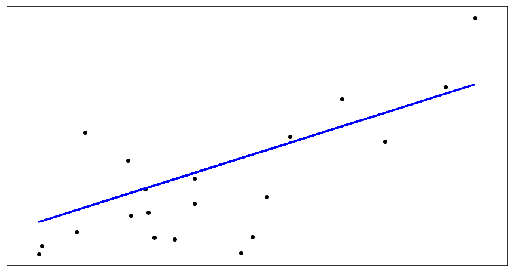

```python
plt.scatter(diabetes_X_test, diabetes_y_test,  color='black')
plt.plot(diabetes_X_test, diabetes_y_pred, color='blue', linewidth=3)
plt.xticks(())
plt.yticks(())
plt.show()
plt.figure(figsize=(20,8))
```

### TASK-2:

What can you say about the success of this model that is presented both with parameters and visually?

### Answer

R-squared is a statistical measure of how close the data are to the fitted regression line. ... 0% indicates that the model explains none of the variability of the response data around its mean. 100% indicates that the model explains all the variability of the response data around its mean.

Program decide to linear line try to minimize mean squared error.

```
Training set score: 0.95
Test set score: 0.61
Training set score: 0.89
Test set score: 0.75
Training set score: 0.79
Test set score: 0.64
Training set score: 0.93
Test set score: 0.77
```

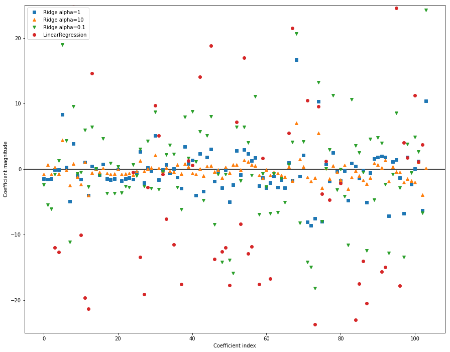

```python
%matplotlib inline
import mglearn
import matplotlib.pyplot as plt
from sklearn.datasets import load_breast_cancer
from sklearn.linear_model import LinearRegression
from sklearn.model_selection import train_test_split  # some documents still include the cross-validation option but it no more exists in version 18.0
import pylab as plt
from sklearn.linear_model import Ridge

X, y = mglearn.datasets.load_extended_boston()
X_train, X_test, y_train, y_test = train_test_split(X, y, random_state=0)
lr = LinearRegression().fit(X_train, y_train)

print("Training set score: {:.2f}".format(lr.score(X_train, y_train)))
print("Test set score: {:.2f}".format(lr.score(X_test, y_test)))  # Overfit

ridge = Ridge().fit(X_train, y_train)
print("Training set score: {:.2f}".format(ridge.score(X_train, y_train)))
print("Test set score: {:.2f}".format(ridge.score(X_test, y_test)))

ridge10 = Ridge(alpha=10).fit(X_train, y_train)
print("Training set score: {:.2f}".format(ridge10.score(X_train, y_train)))
print("Test set score: {:.2f}".format(ridge10.score(X_test, y_test)))

ridge01 = Ridge(alpha=0.1).fit(X_train, y_train)
print("Training set score: {:.2f}".format(ridge01.score(X_train, y_train)))
print("Test set score: {:.2f}".format(ridge01.score(X_test, y_test)))
plt.figure(figsize=(15,12))
plt.plot(ridge.coef_, 's', label="Ridge alpha=1")
plt.plot(ridge10.coef_, '^', label="Ridge alpha=10")
plt.plot(ridge01.coef_, 'v', label="Ridge alpha=0.1")
plt.plot(lr.coef_, 'o', label="LinearRegression")

plt.xlabel("Coefficient index")
plt.ylabel("Coefficient magnitude")
xlims = plt.xlim()
plt.hlines(0, xlims[0], xlims[1])
plt.xlim(xlims)
plt.ylim(-25, 25)
plt.legend()
```

```python
ridge09 = Ridge(alpha=0.09).fit(X_train, y_train)
print("Training set score: {:.2f}".format(ridge09.score(X_train, y_train)))
print("Test set score: {:.2f}".format(ridge09.score(X_test, y_test)))
```

```
Training set score: 0.93
Test set score: 0.77
```

```python
ridge08 = Ridge(alpha=0.8).fit(X_train, y_train)
print("Training set score: {:.2f}".format(ridge08.score(X_train, y_train)))
print("Test set score: {:.2f}".format(ridge08.score(X_test, y_test)))
```

```
Training set score: 0.89
Test set score: 0.76
```

```python
ridge087 = Ridge(alpha=0.87).fit(X_train, y_train)
print("Training set score: {:.2f}".format(ridge087.score(X_train, y_train)))
print("Test set score: {:.2f}".format(ridge087.score(X_test, y_test)))
```

```
Training set score: 0.89
Test set score: 0.76
```

### TASK-3:

What are different penalty scores that are attempted for this Ridge model? What is the effect of this penalty terms? Which one (among these three) is better and why?

```
Training set score: 0.29
Test set score: 0.21
Number of features used: 4
Training set score: 0.90
Test set score: 0.77
Number of features used: 33
Training set score: 0.95
Test set score: 0.64
Number of features used: 94
```

```
Text(0,0.5,'Coefficient magnitude')
```

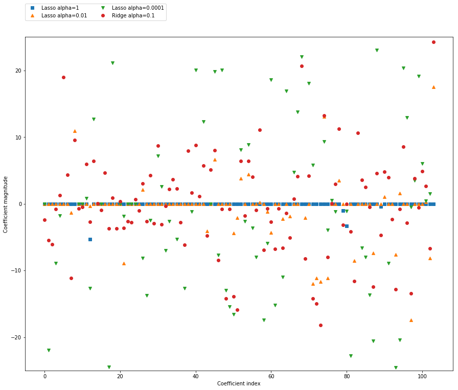

```python
from sklearn.linear_model import Lasso

lasso = Lasso().fit(X_train, y_train)
print("Training set score: {:.2f}".format(lasso.score(X_train, y_train)))
print("Test set score: {:.2f}".format(lasso.score(X_test, y_test)))
print("Number of features used: {}".format(np.sum(lasso.coef_ != 0)))

# We increase the default setting of "max_iter",
# otherwise the model would warn us that we should increase max_iter.
lasso001 = Lasso(alpha=0.01, max_iter=100000).fit(X_train, y_train)
print("Training set score: {:.2f}".format(lasso001.score(X_train, y_train)))
print("Test set score: {:.2f}".format(lasso001.score(X_test, y_test)))
print("Number of features used: {}".format(np.sum(lasso001.coef_ != 0)))

lasso00001 = Lasso(alpha=0.0001, max_iter=100000).fit(X_train, y_train)
print("Training set score: {:.2f}".format(lasso00001.score(X_train, y_train)))
print("Test set score: {:.2f}".format(lasso00001.score(X_test, y_test)))
print("Number of features used: {}".format(np.sum(lasso00001.coef_ != 0)))
plt.figure(figsize=(15,12))
plt.plot(lasso.coef_, 's', label="Lasso alpha=1")
plt.plot(lasso001.coef_, '^', label="Lasso alpha=0.01")
plt.plot(lasso00001.coef_, 'v', label="Lasso alpha=0.0001")

plt.plot(ridge01.coef_, 'o', label="Ridge alpha=0.1")
plt.legend(ncol=2, loc=(0, 1.05))
plt.ylim(-25, 25)
plt.xlabel("Coefficient index")
plt.ylabel("Coefficient magnitude")
```

```python
lasso001 = Lasso(alpha=0.007, max_iter=100000).fit(X_train, y_train)
print("Training set score: {:.2f}".format(lasso001.score(X_train, y_train)))
print("Test set score: {:.2f}".format(lasso001.score(X_test, y_test)))
print("Number of features used: {}".format(np.sum(lasso001.coef_ != 0)))
```

```
Training set score: 0.91
Test set score: 0.78
Number of features used: 38
```

### TASK-4:

Would you please explain these 3 different Lasso models?

### Answer

When lasso alpha = 1 model drops so many features and genaralize model so much so model is underfitting. when lasso alpha = 0.01 model takes 33 features and give r squared 0.77.(best one amongs these three.)

### LOGISTIC REGRESSION

###### #

http://scikit-learn.org/stable/auto_examples/linear_model/plot_logistic_l1_l2_sparsity.html#sphx-glr-auto-examples-linear-model-plot-logistic-l1-l2-sparsity-py

```python
import numpy as np
import pandas as pd
# import model
from sklearn.linear_model import LinearRegression
from sklearn.model_selection import train_test_split

# import module to calculate model perfomance metrics
from sklearn import metrics


data_path = "/Users/yetkineser/Desktop/BDA 502/week 4/DATA.csv" # or load the dataset directly from the link
# # data_link = "http://www-bcf.usc.edu/~gareth/ISL/Advertising.csv"

data = pd.read_csv(data_path, index_col=0)

# create a Python list of feature names
feature_names = ['TV', 'radio','newspaper']

# use the list to select a subset of the original DataFrame
X = data[feature_names]

# getting sales as the target value
y = data.sales

# Splitting X and y into training and testing sets
X_train, X_test, y_train, y_test = train_test_split(X, y, random_state=1)

# Linear Regression Model
linreg = LinearRegression()

# fit the model to the training data (learn the coefficients)
linreg.fit(X_train, y_train)

# make predictions on the testing set
y_pred = linreg.predict(X_test)

# compute the RMSE of our predictions
print(np.sqrt(metrics.mean_squared_error(y_test, y_pred)))
```

```
1.40465142303
```

```python
data.head()
```

|  | TV | radio | newspaper | sales |
| --- | --- | --- | --- | --- |
| 1 | 230.1 | 37.8 | 69.2 | 22.1 |
| 2 | 44.5 | 39.3 | 45.1 | 10.4 |
| 3 | 17.2 | 45.9 | 69.3 | 9.3 |
| 4 | 151.5 | 41.3 | 58.5 | 18.5 |
| 5 | 180.8 | 10.8 | 58.4 | 12.9 |

### TASK-5:

**1.** Place the relevant file DATA.csv into the related project folder download it from http://www-bcf.usc.edu/~gareth/ISL/Advertising.csv

**2.** Quick Analysis and Visualization

**3.** Train linear regression model and two of other models

**4.** Show the Learned estimators/coefficients **5.** Model Evaluation of these models and compare your findings

```python
lr = LinearRegression().fit(X_train, y_train)

print("Training set score: {:.2f}".format(lr.score(X_train, y_train)))
print("Test set score: {:.2f}".format(lr.score(X_test, y_test)))  # Overfit
```

```
Training set score: 0.89
Test set score: 0.92
```

```python
ridge10000 = Ridge(alpha=10000).fit(X_train, y_train)
print("Training set score: {:.2f}".format(ridge10000.score(X_train, y_train)))
print("Test set score: {:.2f}".format(ridge10000.score(X_test, y_test)))
```

```
Training set score: 0.88
Test set score: 0.87
```

```python
lasso09 = Lasso(alpha=0.9, max_iter=100000).fit(X_train, y_train)
print("Training set score: {:.2f}".format(lasso09.score(X_train, y_train)))
print("Test set score: {:.2f}".format(lasso09.score(X_test, y_test)))
print("Number of features used: {}".format(np.sum(lasso09.coef_ != 0)))
```

```
Training set score: 0.89
Test set score: 0.91
Number of features used: 3
```

[output not shown]

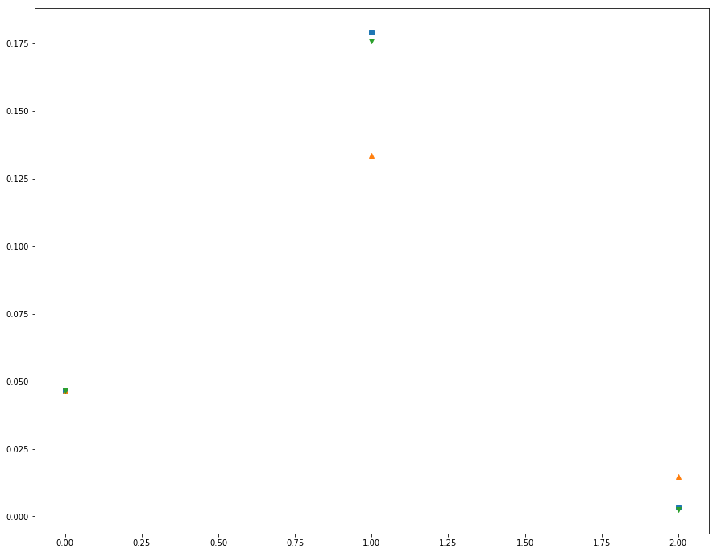

```python
plt.figure(figsize=(15,12))
plt.plot(lr.coef_, 's', label="Linear")
plt.plot(ridge10000.coef_, '^', label="Ridge alpha=10000")
plt.plot(lasso09.coef_, 'v', label="Lasso alpha=0.9")
plt.hlines(0, xlims[0], xlims[0.2])

plt.legend(ncol=2, loc=(0, 1.05))
plt.ylim(-1, 1)
plt.xlabel("Coefficient index")
plt.ylabel("Coefficient magnitude")
```